# FuelWatch Project

## Data Download Script (`data_download.py`)

#The datasets used in this project are **not stored in the GitHub repository**. Instead, they are downloaded locally using the script “data_download.py”.

#This script downloads the monthly FuelWatch retail price data directly from the official website of the Western Australia Government. It automatically:

#- Creates a local `data/` folder if it does not exist #- Builds the correct download links for each month #- Downloads the available CSV files into the `data/` folder

#The CSV files are ignored by Git and are therefore not uploaded to GitHub. This keeps the repository clean and avoids storing large data files.

#To download the data, run the script from the project directory:

#bash #python data_download.py

##Set Up

```python
import pandas as pd
import numpy as np
import matplotlib.pyplot as plt
import seaborn as sns
from pathlib import Path  # for the path of the data
from sklearn.cluster import KMeans
```

## Data import and standardization

```python
#loading and cleaning data
data_path = Path("data")  # folder where the CSV files are stored
files = sorted(data_path.glob("FuelWatchRetail-*.csv"))  # Collects all monthly CSV files

data = pd.concat(
    [pd.read_csv(f) for f in files],
    ignore_index=True
)  # combining all csv files

if "Unnamed: 10" in data.columns:
    data = data.drop(columns=["Unnamed: 10"])  #dropping unnecesary columns

data = data.rename(
    columns={
        "REGION_DESCRIPTION": "REGION",
        "AREA_DESCRIPTION": "AREA",
        "BRAND_DESCRIPTION": "BRAND",
        "PRODUCT_PRICE": "PRICE"  #
    }
)  #Renaming columns

required_cols = ["REGION", "AREA", "BRAND", "PRICE", "TRADING_NAME", "PUBLISH_DATE", "PRODUCT_DESCRIPTION"]
missing_cols = [c for c in required_cols if c not in data.columns]

if len(missing_cols) > 0:
    raise KeyError(f"After renaming, these required columns are missing: {missing_cols}. Available columns: {list(data.columns)}")  #avoids error after renaming

data = data[data["PRODUCT_DESCRIPTION"] == "ULP"]  # taking only ULP rows

data["DATE"] = pd.to_datetime(  # Convert publish date to datetime
    data["PUBLISH_DATE"],
    dayfirst=True,  # dd/mm/yyyy cases
    errors="coerce"
)

data = data.dropna(subset=["DATE"])  # droping NANas

weekday_order = ["Monday", "Tuesday", "Wednesday", "Thursday", "Friday", "Saturday", "Sunday"]  # Defines weekday order
data["WEEKDAY"] = pd.Categorical(
    data["DATE"].dt.day_name(),
    categories=weekday_order,
    ordered=True
)

list(data.columns)
```

```
['PUBLISH_DATE',
 'TRADING_NAME',
 'BRAND',
 'PRODUCT_DESCRIPTION',
 'PRICE',
 'ADDRESS',
 'LOCATION',
 'POSTCODE',
 'AREA',
 'REGION',
 'DATE',
 'WEEKDAY']
```

## Overview: Regions, Areas, and Brands

# Observations by region

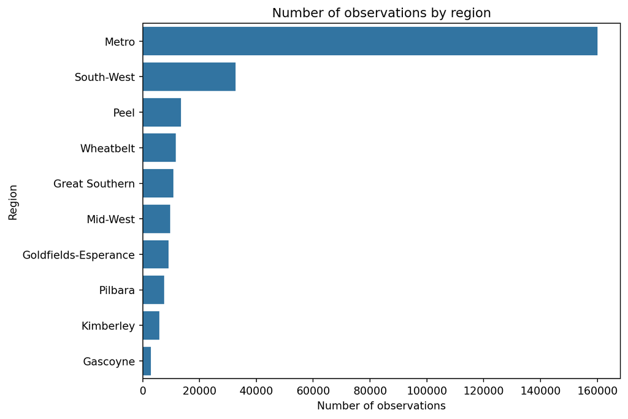

```python
region_counts = data["REGION"].value_counts().reset_index()

region_counts.columns = ["REGION", "N"]  # renaming columns avoding errosrs

plt.figure(figsize=(8, 6))
sns.barplot(data=region_counts, y="REGION", x="N")

plt.title("Number of observations by region")
plt.xlabel("Number of observations")
plt.ylabel("Region")
plt.show()
```

Most data points are located in the Metro region while, other regions have significantly fewer observations.

# Observations by brand and region

[figure not shown]

```python
brand_region = (
    data
    .groupby(["BRAND", "REGION"])  # Group by brand and region
    .size()
    .reset_index(name="N")
)

plt.figure(figsize=(10, 6))
sns.barplot(data=brand_region, x="BRAND", y="N", hue="REGION")
plt.title("Observatons by brand and region")
plt.xlabel("Brand")
plt.ylabel("Number of observations")
plt.legend(title="Region", bbox_to_anchor=(0.5, -0.25), loc="upper center", ncol=3)
plt.show()
```

# Overall average price

```python
overall_avg_price = data["PRICE"].mean()
overall_avg_price

print ("Overall average price:", overall_avg_price)
```

```
Overall average price: 177.16230802734492
```

# Average price over time

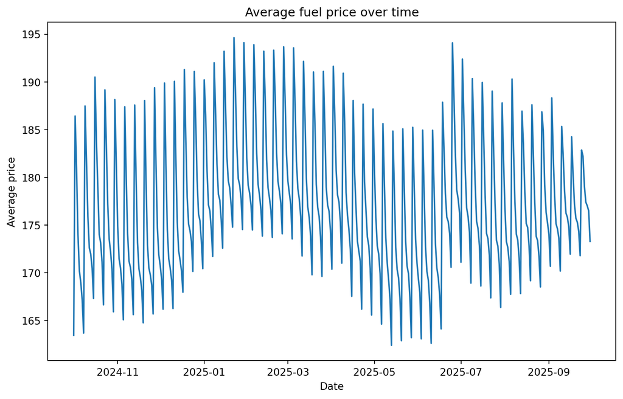

```python
avg_price_date = (
    data
    .groupby("DATE", as_index=False)
    .agg(AVG_PRICE=("PRICE", "mean"))
)

plt.figure(figsize=(10, 6))
sns.lineplot(data=avg_price_date, x="DATE", y="AVG_PRICE")
plt.title("Average fuel price over time")
plt.xlabel("Date")
plt.ylabel("Average price")
plt.show()
```

There is a clear long-term trend with periods of increase and decrease.

# Average price by weekday

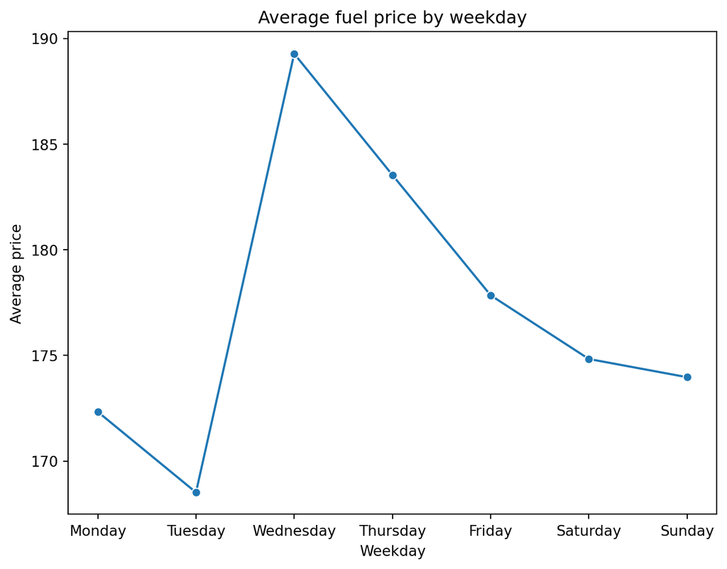

```python
avg_price_weekday = (
    data
    .groupby("WEEKDAY", as_index=False)
    .agg(AVG_PRICE=("PRICE", "mean"))
)

plt.figure(figsize=(8, 6))
sns.lineplot(
    data=avg_price_weekday,
    x="WEEKDAY",
    y="AVG_PRICE",
    marker="o"
)
plt.title("Average fuel price by weekday")
plt.xlabel("Weekday")
plt.ylabel("Average price")
plt.show()
```

# Average price over time by region

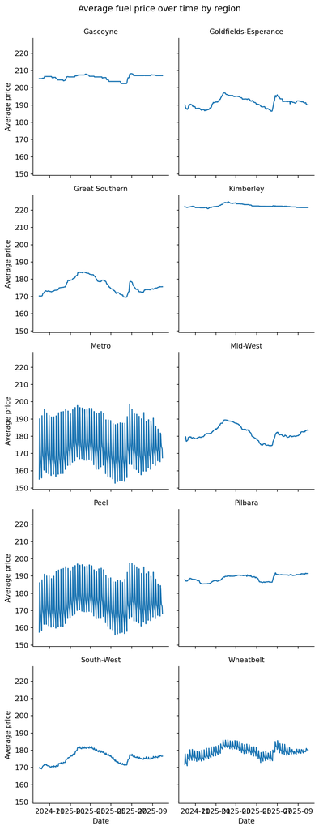

```python
avg_price_date_region = (
    data  # Use the cleaned dataset
    .groupby(["REGION", "DATE"], as_index=False)  # Group by region and date
    .agg(AVG_PRICE=("PRICE", "mean"))
)

g = sns.FacetGrid(
    avg_price_date_region,
    col="REGION",
    col_wrap=2,  # plot it in two columns so it can be visualizated better
    height=3.2,
    sharey=True
)

g.map_dataframe(sns.lineplot, x="DATE", y="AVG_PRICE")  #ploting line visualization
g.set_axis_labels("Date", "Average price")
g.set_titles(col_template="{col_name}")
g.fig.suptitle("Average fuel price over time by region", y=1.02)  #
plt.show()
```

Strong oscillations are visible in Metro and Peel regions.While in other regons it is more stable.

## Characterization Price Dynamics

# Data Trasnsformation

```python
data["N_OBS_TRADING_NAME"] = (  # station level for trading
    data
    .groupby(["TRADING_NAME", "BRAND"])["PRICE"]  # Group by station and same brand
    .transform("size")
)

data["MEAN_PRICE"] = (  #station level for mean price feature
    data
    .groupby(["TRADING_NAME", "BRAND"])["PRICE"]  # Group by station and same brand
    .transform("mean")
)

data["SD_PRICE"] = (  #tation level for deviation price feature
    data
    .groupby(["TRADING_NAME", "BRAND"])["PRICE"]  # Group by station and same brand
    .transform("std")
)
```

# Histogram of station-level SD_Price

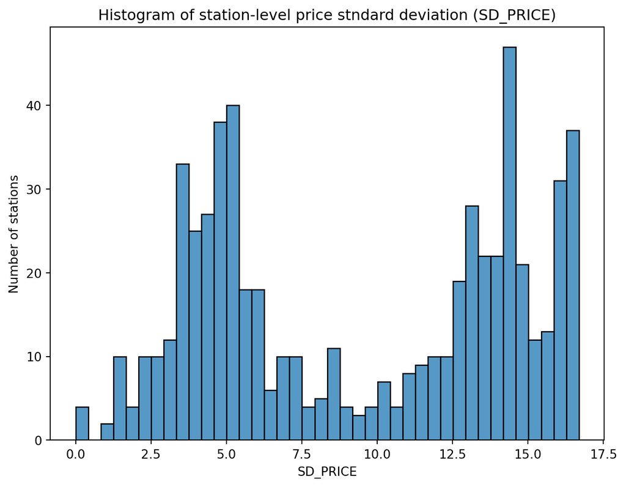

```python
n_days = data["DATE"].nunique()  # total quantity of days in the dataset

data_stations = (
    data
    .loc[data["N_OBS_TRADING_NAME"] == n_days, :]
    .loc[:, ["REGION", "TRADING_NAME", "BRAND", "MEAN_PRICE", "SD_PRICE"]]
    #selecting requred station-level columns
    .drop_duplicates()  #droping duplicates
)

plt.figure(figsize=(8, 6))
sns.histplot(data=data_stations, x="SD_PRICE", bins=40)  #historiogram
plt.title("Histogram of station-level price stndard deviation (SD_PRICE)")
plt.xlabel("SD_PRICE")
plt.ylabel("Number of stations")
plt.show()
```

# Stattions: Mean price vs. price variability by redion

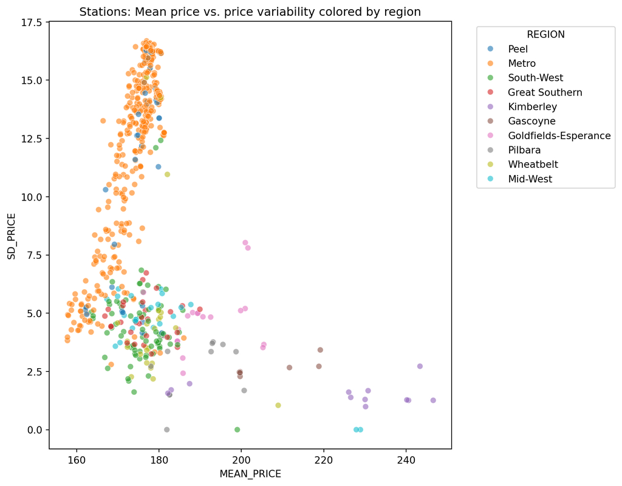

```
Correlation over all stations -0.139646041839078
```

```python
plt.figure(figsize=(9, 7))
sns.scatterplot(
    data=data_stations,  # creatd stationlevel data
    x="MEAN_PRICE",
    y="SD_PRICE",
    hue="REGION",
    alpha=0.6
)

plt.title("Stations: Mean price vs. price variability colored by region")
plt.xlabel("MEAN_PRICE")
plt.ylabel("SD_PRICE")
plt.legend(title="REGION", bbox_to_anchor=(1.05, 1), loc="upper left")
plt.tight_layout()
plt.show()

# Compute correlation over all stations
corr_all = data_stations["MEAN_PRICE"].corr(data_stations["SD_PRICE"])
corr_all

print ("Correlation over all stations", corr_all)
```

Stations with high price variability are mainly located in the Metro region.